# assignment1

Oezge

14.03.2015

### Loading and preprocessing the data

- It is assumed that the file to be read is already in the working directory

```r
filepath <- paste(getwd(), 'activity.csv', sep="/")
actData <- read.csv(file = filepath, stringsAsFactors = FALSE)
actData$date <- as.Date(actData$date)
```

- The data is loaded in a way that anything that can be in format factor will not be allowed and thay are loaded in character format. In this way, the date column is loaded in character format. In the second line, the format of date column is changed to date format, %y%m%d.

### What is mean total number of steps taken per day?

I use functions from dplyr package to subset the data , so I start with uploading it.

```r
library(dplyr)
```

- First and second parts of the question are computed together :

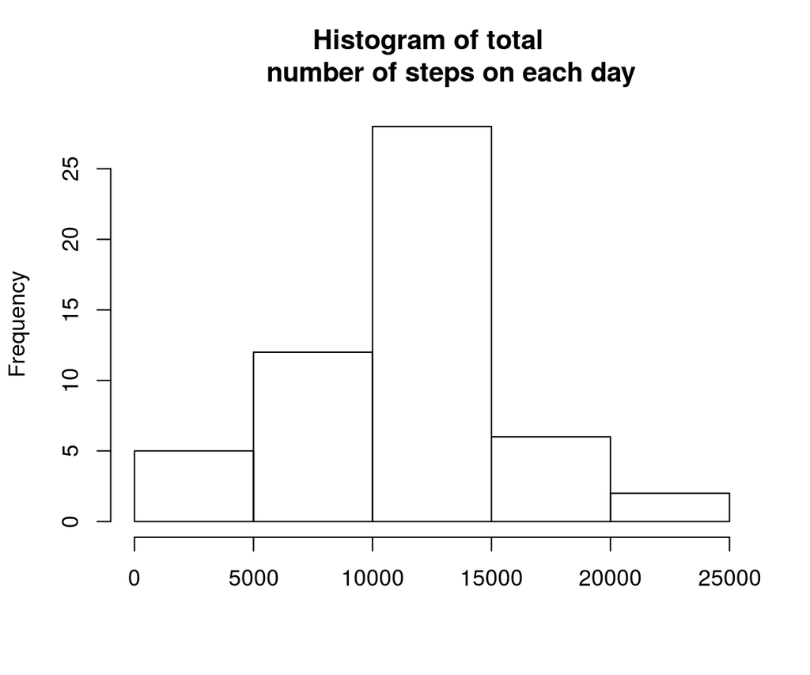

```r
actDataGrp <- group_by(actData,date)
actDataGrp <- na.omit(actDataGrp)
sumSteps <- summarize(actDataGrp, sum(steps))
names(sumSteps) <- c('date', 'sums')
hist(sumSteps$sums, xlab = '', main = "Histogram of total
     number of steps on each day")
```

- Computing mean and median of total number of steps taken per day :

```r
meanSumSteps <- mean(sumSteps$sums)
medianSumSteps <- median(sumSteps$sums)
```

### What is the average daily activity pattern?

In order to plot, I use ggplot2 package, so first it is downloaded

```r
library(ggplot2)
```

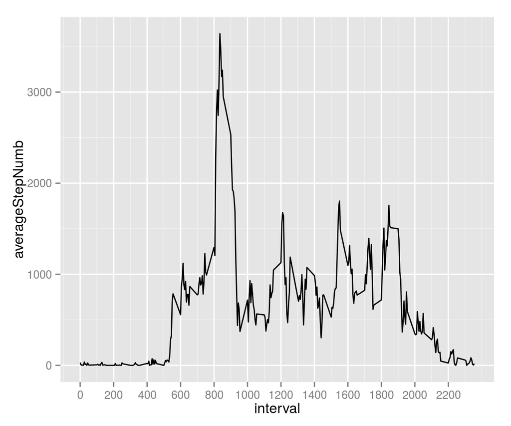

```r
actDataInterval <- na.omit(group_by(actData,interval))
numberDates <- length(unique(actDataInterval))
averagedSteps <- summarize(actDataInterval, sum(steps)/numberDates)
names(averagedSteps) <- c('interval', 'averageStepNumb')
ggplot(data = averagedSteps, aes(interval, averageStepNumb)) + geom_line() +
  scale_x_continuous(breaks= round(seq(min(averagedSteps$interval),
                                       max(averagedSteps$interval), by = 200),1))
```

- From the figure it can be seen that, the maxiumum number of steps are contained by the interval that is between 800th and 900th.

### Imputing missing values

- The first question asks the number of missing values in the data frame.

```r
numNA <- length(which(is.na(actData)))
```

The number of missing values in the original data is 2304.

- The second question asks to develop a strategy to replace NA values.

I prefer to replace all NA values with 0’s.

- The third question asks to implement this strategy to a new data set

```r
actDataNoMiss <- actData
actDataNoMiss$steps[which(is.na(actData))] <- rep(0, numNA)
```

- The fourth question asks to make a histogram as in the first part and compare the results

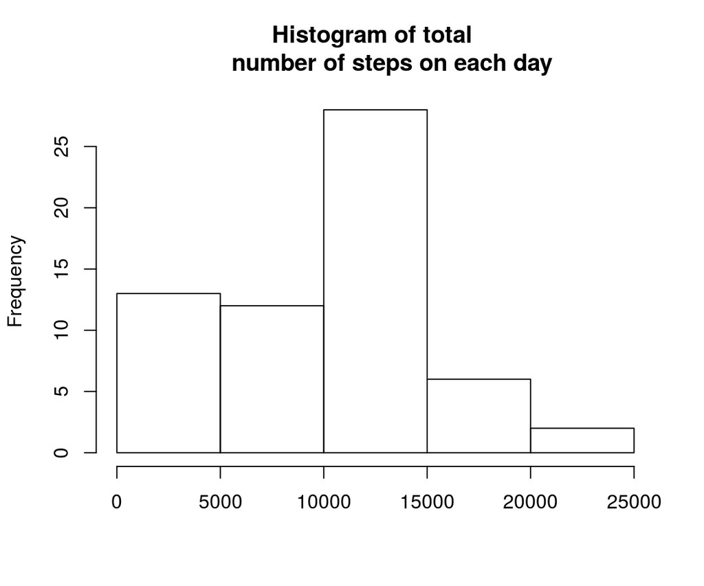

```r
actDataGrpNoMiss <- group_by(actDataNoMiss,date)
sumStepsNoMiss <- summarize(actDataGrpNoMiss, sum(steps))
names(sumStepsNoMiss) <- c('date', 'sums')
hist(sumStepsNoMiss$sums, xlab = '', main = "Histogram of total
     number of steps on each day")
```

Computing mean and median of total number of steps taken per day :

```r
meanSumStepsNoMiss <- mean(sumStepsNoMiss$sums)
medianSumStepsNoMiss <- median(sumStepsNoMiss$sums)
```

### Are there differences in activity patterns between weekdays and weekends?

- The first question asks to create a new data set with two levels : weekdays and weekend

```r
weekdays <-(weekdays(actDataNoMiss$date))
actDataNoMiss$weekdays <- as.factor(weekdays)
levels(actDataNoMiss$weekdays) <- c('weekday','weekday','weekday','weekday',
                                    'weekday','weekend','weekend')
```

- The second question asks to make a time series plot of the 5-minute interval and the average number of steps taken, averaged across all weekday days or weekend days.

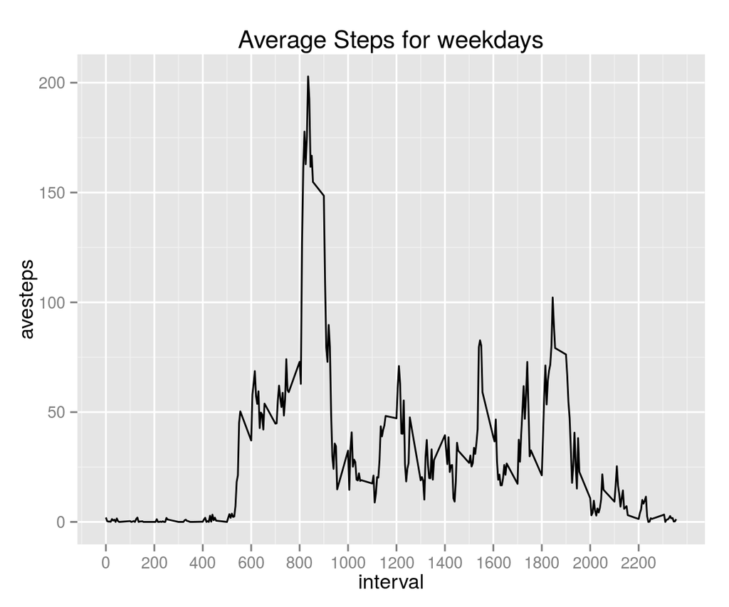

```r
actDataNoMiss_wdays <- filter(actDataNoMiss, actDataNoMiss$weekdays == 'weekday')
actDataNoMiss_wend <- filter(actDataNoMiss, actDataNoMiss$weekdays == 'weekend')

AveSteps_wdays <-summarize(group_by(actDataNoMiss_wdays, interval),mean(steps))
AveSteps_wend <-summarize(group_by(actDataNoMiss_wend, interval),mean(steps))
names(AveSteps_wdays) <- c('interval','avesteps')
names(AveSteps_wend) <- c('interval','avesteps')
ggplot(data = AveSteps_wdays, aes(interval, avesteps)) + geom_line() +
              scale_x_continuous(breaks= round(seq(min(AveSteps_wdays$interval),
                                                   max(AveSteps_wdays$interval),
                                                   by = 200),1)) +
                                                   ggtitle("Average Steps for weekdays")
```

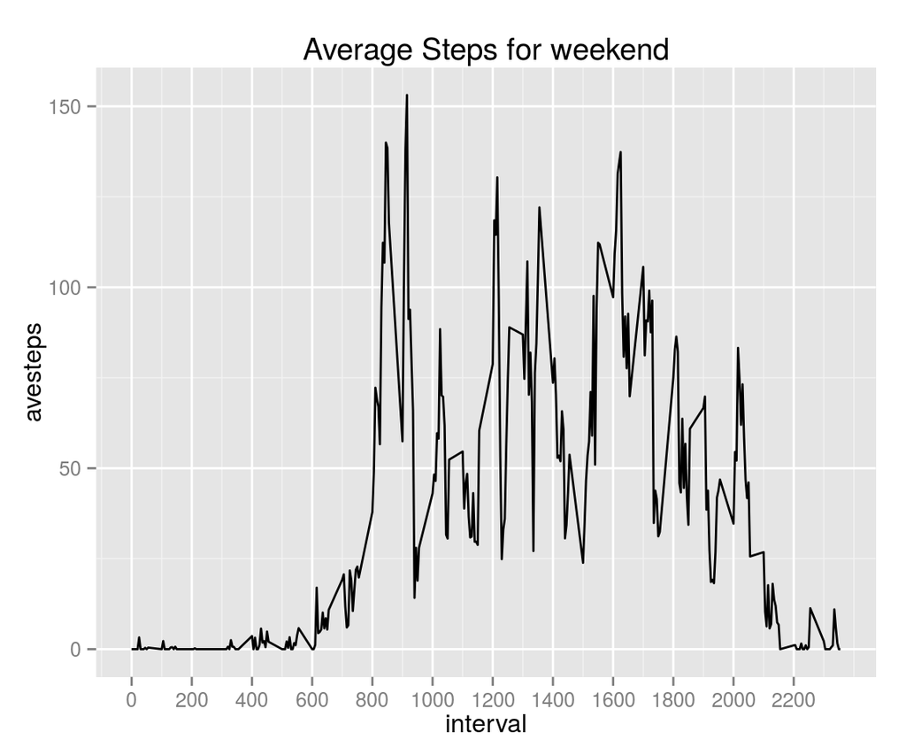

```r
ggplot(data = AveSteps_wend, aes(interval, avesteps)) + geom_line() +
              scale_x_continuous(breaks= round(seq(min(AveSteps_wend$interval),
                                                   max(AveSteps_wend$interval),
                                                   by = 200),1)) +
                                                     ggtitle("Average Steps for weekend")
```